# Day 1 Survey Visualization

Lucy D’Agostino McGowan

2019-08-27

An instructor at a small liberal arts college distributed a data collection card to students on the first day of class. The data for two different sections of the course are shown in the dataset called `Day1Survey`.

Let’s first load the packages, tidyverse and Stat2Data as well as the `Day1Survey` dataset.

```r
library(tidyverse)
library(Stat2Data)
data("Day1Survey")
```

This dataset is comprised of `observations` (rows) and `variables` (columns). There are two types of variables, `quantitative` variables and `categorical` variables.

## Quantitative variables

A `quantitative` variable is numeric, that is it records a number about the observation. These numbers must be able to have arithmetic sensibly performed on them. For example, a zip code, while numeric, is not `quantitative` since it wouldn’t make sense to add two zip codes together.

In the `Day1Survey` dataset, there are the following `quantitative` variables:

- `Distance` Distance (in miles) to get to campus
- `Height` Height (in inches)
- `Coins` Value of coins student has (in class)
- `WhiteString` Estimated length of a white string (in inches)
- `BlackString` Estimated length of a black string (in inches)
- `Reading` Expected amount of reading during the semester (pages/week)
- `TV` Hours of TV watched per week
- `Pulse` Resting pulse rate (beats per minute)
- `Texting` Number of text messages in past 24 hours

## Categorical variables

A `categorical` variable is a variable that records a category about an observation. If there are only two categories, this is known as a `binary` variable.

In the `Day1Survey` dataset, there are the following `categorical` variables:

- `Section` Section: 1 or 2
- `Class` Year in school: Freshman, Sophomore, Junior, or Senior
- `Sex` F=female or M=male
- `Handedness` Left, Right, or Ambidextrous

Section and Sex are examples of `binary` variables. Since section is saved as a numeric variable, `R` thinks that it is quantitative. We can teach it that it is categorical by saving it as a `factor`. Let’s create a new dataset called `data` that does this.

```r
data <- Day1Survey %>%
  mutate(Section = factor(Section))
```

## Data cleaning

There is some missing data in this dataset. The variable `Class` has one record with `"N/A"` and one record with `*`. In `R`, there is a special designation for missingness `<NA>`. Let’s update these codes and update the factor levels.

```r
data <- data %>%
  mutate(Class = na_if(Class, "N/A"),
         Class = na_if(Class, "*"),
         Class = factor(Class,
                        levels = c("Freshman", "Sophomore", "Junior", "Senior"))
  )
```

## Visualize it!

Let’s look at the distribution of `TV` by `Class` using boxplots with the observed data points jittered on top.

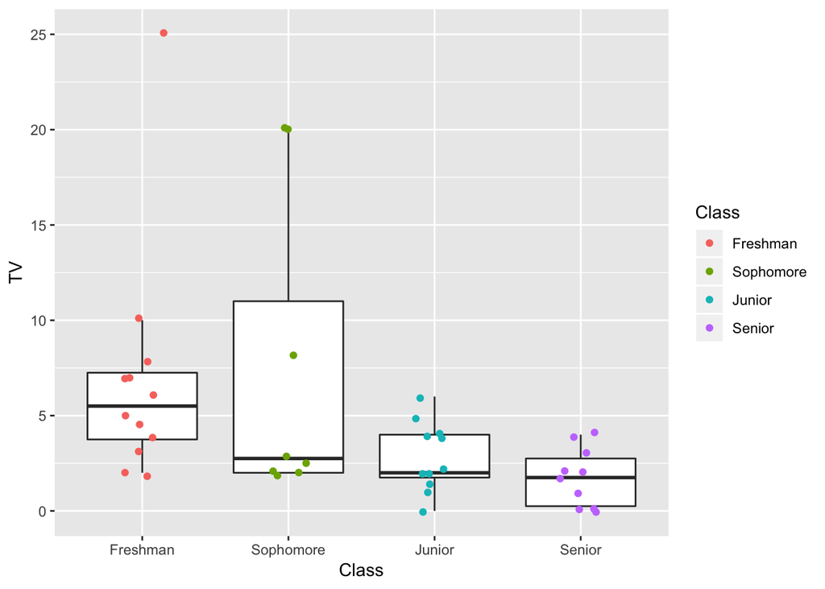

```r
data %>%
  filter(!is.na(Class)) %>%
ggplot(mapping = aes(Class, TV)) +
  geom_boxplot(outlier.shape = NA) +
  geom_jitter(width = 0.15, aes(color = Class))
```